# Integrative analysis of metabolome and microbiome

Congcong Gong

```r
library(data.table)
library(mbOmic)
```

# Introduction

The `mbOmic` package contains a set of analysis functions for microbiomics and metabolomics data, designed to analyze the inter-omic correlation between microbiology and metabolites, referencing the workflow of Jonathan Braun et al[^1].

```r
knitr::include_graphics('./img/mbOmic-workflow.svg')
```

[figure not shown]

# Examples

Load metabolites and OTU abundance data of plant.[^2] The OTU had been binned into genera level and were save as the metabolites_and_genera.rda file

```r
path <- system.file('data',package = 'mbOmic')
load(file.path(path,'metabolites_and_genera.rda'))
```

## Construct the `mbSet` object.

`mbSet` is S4 class containing the metabolites and OTU abundance.

We can use `mbSet` function to create directrly `mbSet` class.

```r
mb <-
  mbSet(
      m = metabolites,
    b = genera
  )
```

Extract the samples names from `mbSet` class by `samples.extra` function.

```r
samples.extra(mb)
```

```
#>  [1] "BS1" "BS2" "BS3" "BS4" "BS5" "BS6" "SS1" "SS2" "SS3" "SS4" "SS5" "SS6"
```

```r
nb <- nb.extra(mb)
nm <- nm.extra(mb)
cat("The mb object contains", nb, "generas and", nm, "metabolites\n")
```

```
#> The mb object contains 18 generas and 247 metabolites
```

## Remove bad analytes (OTU and metatoblites)

Removal of analytes only measured in <2 of samples can perform by `clean_analytes`.

```r
mb <- clean_analytes(mb,m_thres = 2,b_thres = 2)
```

## Generate metabolite module

The WGCNA package is used to generate metabolite modules. The first step is to pick up the softthreshold. This processs is enclosed into `wgcna` function of `mbOmic`. The `threshold.d` and `threshold` parameters are used to detect whether is $R^2$ changing and appropriate.

```r
net <- try({
  wgcna(mb,message = FALSE,threshold.d = 0.02, threshold = 0.8)
})
```

```
#>
#> All metabolites are ok!
#>
#> One: detect the power for softThreshold
```

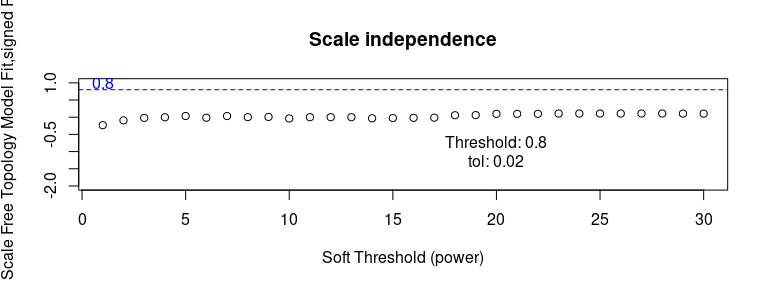

```
#> Error in wgcna(mb, message = FALSE, threshold.d = 0.02, threshold = 0.8) :
#>   No power detected! pls set the power parameter
class(net)
#> [1] "try-error"
```

If you can’t get a good scale-free topology index no matter how high set the soft-thresholding power, you can set directly the power by the parameter `power`. The appropriate soft-thresholding power can be chosen based on the number of samples as in the table below (recommend by the authors of `WGCNA` package).

| **Number of samples** | **Unsigned and signed hybrid networks** | **Signed networks** |
| --- | --- | --- |
| <20 | 9 | 18 |
| 20~30 | 8 | 16 |
| 30~40 | 7 | 14 |
| >40 | 6 | 12 |

```r
net <- wgcna(mb,message = FALSE,threshold.d = 0.02, threshold = 0.8, power = 9)
```

```
#>
#> All metabolites are ok!
#>
#> One: detect the power for softThreshold
```

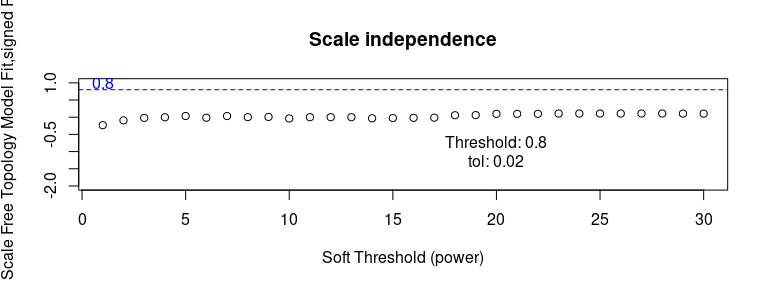

```
#>
#> using the powser:  9 to constructe net!
#>
#> Two: Automatic network construction and module detection by one-step method
```

Result Visualization is performed by function `plotDendroAndColors` of `WGCNA` package.

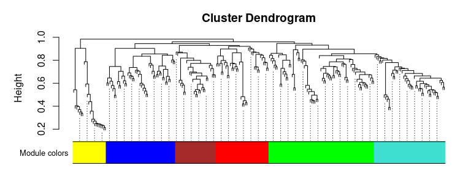

```r
plot_wgcna(net)
```

## Calculate the Spearman metabolite-genera correlation

you can calculate the Spearman correlation between metabolites and OTUs by `corr` function. It return a data table containing `rho`, `p value`, and `adjust p value`.

```r
res <- corr(mb, method = 'spearman')
head(res)
```

```
#>                         b           m        rho           p padj
#> 1:            Acidibacter Delavirdine  0.6853147 0.013905969    1
#> 2:           Acidothermus Delavirdine  0.7272727 0.007355029    1
#> 3:       Anaeromyxobacter Delavirdine -0.7762238 0.002992864    1
#> 4: Candidatus_Udaeobacter Delavirdine -0.6993007 0.011374199    1
#> 5:           Chujaibacter Delavirdine  0.6223776 0.030675895    1
#> 6:           Conexibacter Delavirdine  0.5804196 0.047855977    1
```

## plot the network

Finally, you can vaisulize the network by `plot_network` function, taking the `wgcna` and `corr` output. The orange nodes correspondes to OTU(genera)).

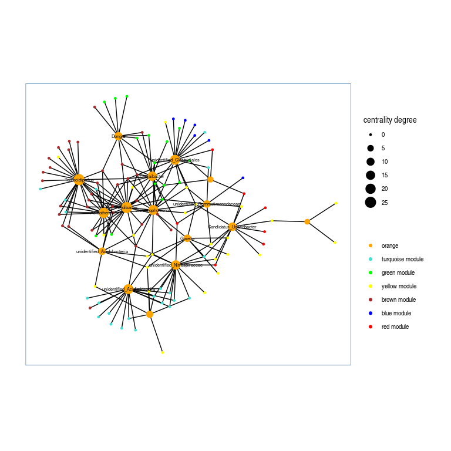

```r
plot_network(net, res[abs(rho)>=0.85])
```

[^1]: McHardy, I. H., Goudarzi, M., Tong, M., Ruegger, P. M., Schwager, E., Weger, J. R., Graeber, T. G., Sonnenburg, J. L., Horvath, S., Huttenhower, C., McGovern, D. P., Fornace, A. J., Borneman, J., & Braun, J. (2013). Integrative analysis of the microbiome and metabolome of the human intestinal mucosal surface reveals exquisite inter-relationships. *Microbiome*, *1*(1), 17. https://doi.org/10.1186/2049-2618-1-17
[^2]: Huang, W., Sun, D., Chen, L., & An, Y. (2021). Integrative analysis of the microbiome and metabolome in understanding the causes of sugarcane bitterness. Scientific Reports, 11(1), 1-11.